# Visualization with *ggplot2*

## On what dimensions?

```r
ggplot(penguins, aes(x = body_mass_g)) + # the + is a bit like %>%
  xlim(2000, 8000)
```

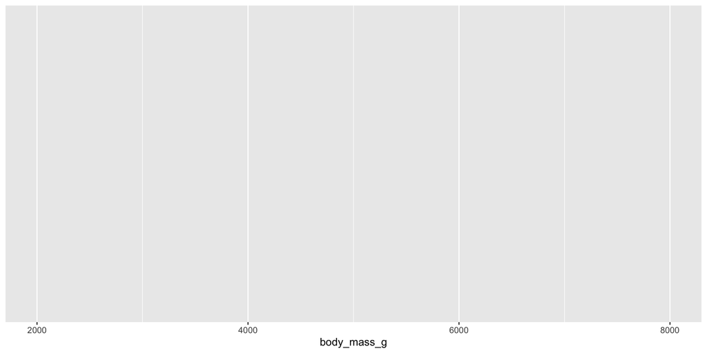

## What to visualize? (“geom”)

```r
ggplot(penguins, aes(x = body_mass_g)) +
  xlim(2000, 8000) +
  geom_histogram()
```

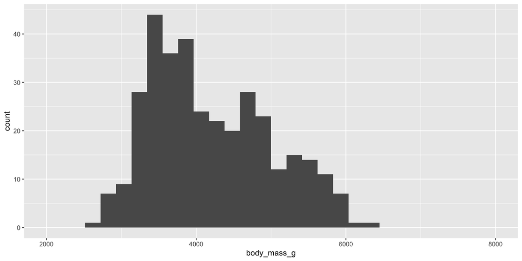

## How to visualize it? (`fill` “aesthetic”)

```r
ggplot(penguins, aes(x = body_mass_g, fill = species)) +
  xlim(2000, 8000) +
  geom_histogram()
```

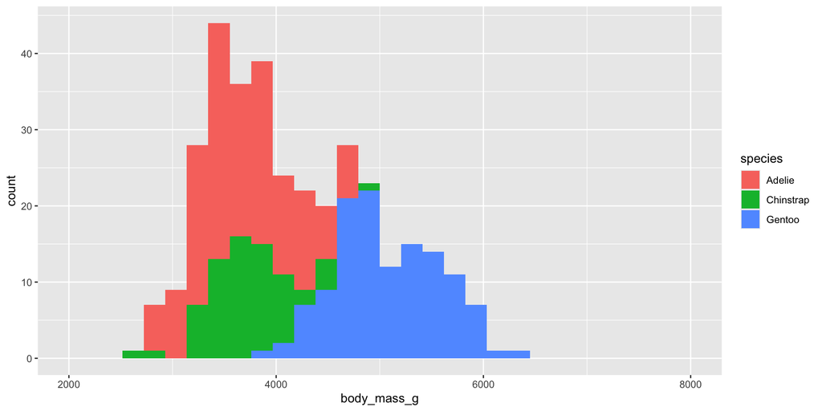

## How to visualize it? (adding “facets”)

```r
ggplot(penguins, aes(x = body_mass_g, fill = species)) +
  xlim(2000, 8000) +
  geom_histogram() +
  facet_wrap(~ species)
```

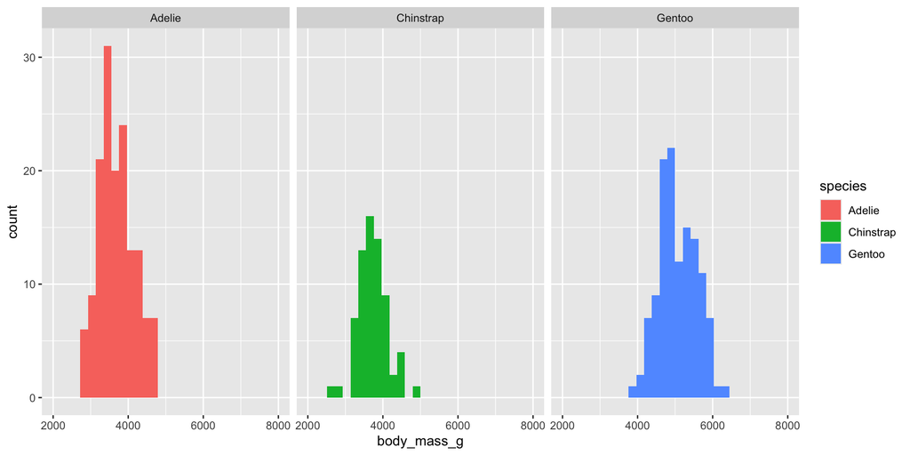

## What to visualize? (“geom” again)

```r
ggplot(penguins, aes(x = body_mass_g, fill = species)) +
  xlim(2000, 8000) +
  geom_density() +
  facet_wrap(~ species)
```

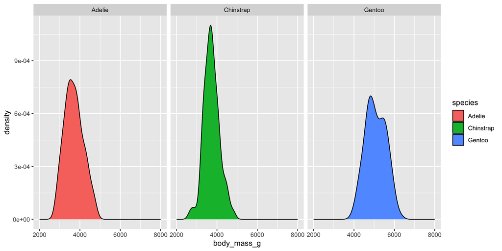

## More “layers”…

```r
ggplot(penguins, aes(x = body_mass_g, fill = species)) +
  xlim(2000, 8000) +
  geom_density() +
  facet_wrap(~ species) +
  theme_minimal()
```

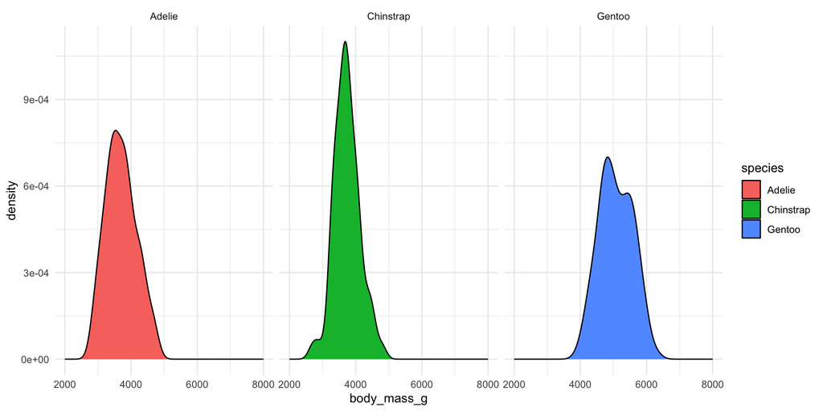

# Today we’re going to learn *ggplot2* on our metadata and IBD data

# A bit of catch-up work on IBDs from yesterday

We need to make a copy of an IBD processing pipeline.

# Let’s get started!

1. Go to [www.bodkan.net/simgen](https://bodkan.net/simgen)
2. Click on *“Visualization with *ggplot2*”* in the left panel
3. *“Cheatsheets and handouts”* section in the left panel has a single-page version of these slides and the *dplyr* cheatsheet and *ggplot2* cheatsheets
4. Open your RStudio and start working!

*ggplot2* version 4.0.0 was released just a few days ago. 🤞😬